[figure not shown]

# PCA, UMAP and t-SNE on single-cell data | Python

Home | About | Projects | Publications

# PCA, UMAP and t-SNE on single-cell data

In this notebook I process the 10x PBMC 3k dataset from raw counts to a 10-PC representation, and then reduce it to 2D in three ways: PCA, UMAP and t-SNE.

The goal is to understand what each of these pictures tell about the cells, and what their limitations are. To test this, I also rerun UMAP and t-SNE with different settings on exactly the same data and look at how much the result changes.

```python
import warnings
warnings.filterwarnings("ignore")

import numpy as np
import pandas as pd
from scipy import sparse
import scanpy as sc
import umap
import matplotlib as mpl
import matplotlib.pyplot as plt
from matplotlib.lines import Line2D
from sklearn.preprocessing import StandardScaler
from sklearn.decomposition import PCA
from sklearn.neighbors import NearestNeighbors
from sklearn.manifold import TSNE
```

## The Dataset

The dataset used for this project is the 10x Genomics PBMC 3k dataset, featuring 2,700 peripheral blood mononuclear cells (PBMCs) from a healthy donor, sequenced on the Illumina NextSeq 500 sequencer. This is the canonical teaching dataset for both Scanpy and Seurat. I started with some data visualization and filtering.

Since my data is a 10X-formatted mtx directory, I can use the scanpy.read_10x_mtx() function to search the specified directory for three specific files that 10x Genomics outputs: matrix.mtx (the raw counts), genes.tsv (or features.tsv), and barcodes.tsv. I then process them into a unified AnnData object.

```python
adata = sc.read_10x_mtx(
    "data/pbmc3k/filtered_gene_bc_matrices/hg19/",
    var_names = "gene_symbols",
    cache = True,
)

# Gene symbols are not always unique (unlike Ensembl ID)
# if the same gene symbol appears >1, append a sufix to the duplicate
adata.var_names_make_unique()

print(adata)
```

```
AnnData object with n_obs × n_vars = 2700 × 32738
    var: 'gene_ids'
    layers: None (.X)
```

adata is an AnnData object (scanpy's container). adata.obs contains one row per cell (metadata) i.e. barcode sequences, and adata.var contains one row per gene using their gene symbol and Ensembl ID. adata.X is the count matrix.

## Quality Control

Three filters are applied: cells with too few (<200) detected genes (empty or dying droplets), genes seen in less than 3 cells (uninformative), and cells with a high fraction (>5%) of mitochondrial reads (since these indicate lysed or stressed cells whose cytoplasmic mRNA has leaked away).

I am keeping the thresholds at the tutorial defaults.

```python
# 1. Computing the per-cell metrics
    # adata.X has columns: genes, rows: cells.
    # axis=1 sums along each row, giving one count per cell.
adata.obs["n_genes"] = np.asarray((adata.X > 0).sum(axis=1)).ravel() # add the number of genes with >0 count for each cell to the metadata as a new column
adata.obs["total_counts"] = np.asarray(adata.X.sum(axis=1)).ravel() # add the total count of genes per cell to the metadata as a new column

mt_mask = adata.var_names.str.startswith("MT-") # var_names holds the names of the cols (genes)
                                                # outputs a Boolean mask (True/False for each col)
adata.obs["pct_mt"] = (
    np.asarray(adata[:, mt_mask].X.sum(axis=1)).ravel()
    / adata.obs["total_counts"] * 100
)

# per-gene metrics
adata.var["n_cells"] = np.asarray((adata.X > 0).sum(axis=0)).ravel() # add the number of cells with >0 count for each gene to the metadata as a new column

print(f"{mt_mask.sum()} mitochondrial genes found by the 'MT-' prefix")
print(f"{100 * adata.X.nnz / (adata.n_obs * adata.n_vars):.2f}% of the matrix is nonzero")
print(f"{(adata.var['n_cells'] < 3).sum()} genes detected in fewer than 3 cells")
print()
print(adata.obs[["n_genes", "total_counts", "pct_mt"]].describe().round(1))
```

```
13 mitochondrial genes found by the 'MT-' prefix
2.59% of the matrix is nonzero
19024 genes detected in fewer than 3 cells

       n_genes  total_counts  pct_mt
count   2700.0        2700.0  2700.0
mean     847.0        2366.9     2.2
std      282.1        1094.3     1.2
min      212.0         548.0     0.0
25%      690.0        1757.8     1.5
50%      817.0        2197.0     2.0
75%      953.2        2763.0     2.6
max     3422.0       15844.0    22.6
```

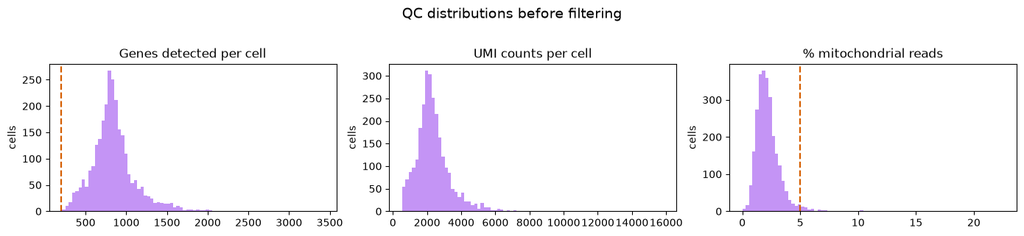

```python
# 2. Plotting per-cell stats before filtering

fig, axes = plt.subplots(1, 3, figsize=(14, 3.1))

panels = [("n_genes",      "Genes detected per cell", 200),
          ("total_counts", "UMI counts per cell",     None),
          ("pct_mt",       "% mitochondrial reads",   5)]

for ax, (col, title, cut) in zip(axes, panels):
    ax.hist(adata.obs[col], bins=80, color="#BA81F4", alpha=0.85)
    if cut is not None:
        ax.axvline(cut, color="#D55E00", lw=1.6, ls="--")
    ax.set_title(title)
    ax.set_ylabel("cells")

fig.suptitle("QC distributions before filtering", y=1.02, fontsize=14)
fig.tight_layout()
plt.show()
```

```python
# 3. Filtering

n0 = adata.n_obs
adata = adata[adata.obs["n_genes"] >= 200].copy()
print(f"min_genes = 200   cells: {n0} -> {adata.n_obs}")

# Recount genes on the surviving cells before filtering them
adata.var["n_cells"] = np.asarray((adata.X > 0).sum(axis=0)).ravel()
n0 = adata.n_vars
adata = adata[:, adata.var["n_cells"] >= 3].copy()
print(f"min_cells = 3     genes: {n0} -> {adata.n_vars}")

n0 = adata.n_obs
adata = adata[adata.obs["pct_mt"] < 5].copy()
print(f"pct_mt < 5        cells: {n0} -> {adata.n_obs}")

print()
print(adata)
```

```
min_genes = 200   cells: 2700 -> 2700
min_cells = 3     genes: 32738 -> 13714
pct_mt < 5        cells: 2700 -> 2643

AnnData object with n_obs × n_vars = 2643 × 13714
    obs: 'n_genes', 'total_counts', 'pct_mt'
    var: 'gene_ids', 'n_cells'
    layers: None (.X)
```

The gene filter removes 19,024 of the 32,738 annotated genes which are seen in fewer than three cells, leaving 13,714 behind. The `min_genes = 200` filter, by contrast, removes nothing at all, which is expected, because these barcodes come from 10x's `filtered_gene_bc_matrices` directory, where empty droplets have already been called and discarded. The mitochondrial filter removes 57 of 2,700 (2.1%) cells, consistent with the histogram above, where the median cell was at 2.0% mitochondrial reads and the tail reaching 22.6% was small. After all filtering, 2,643 cells × 13,714 genes remain: almost every cell is retained, over half the annotation is discarded, all within an expected range.

## Normalization

The UMI counts per cell histogram above shows that cells were sequenced to very different depths in this dataset. Because of this, the genes from cells that have more UMIs will appear as being more highly expressed, which is a consequence of sequencing depth and not representative of the underlying biology. This is also crucial for PCA, which looks at the direction of greatest variance, which would currently be dominated by sequencing depth effects. Therefore, normalization of counts is needed.

#### 1. Depth Normalization

```
5th percentile:  1,013 UMIs
95th percentile: 4,252 UMIs
ratio: 4.2x
```

```
median correlation: 0.06
fraction of genes > 0: 91.2%
```

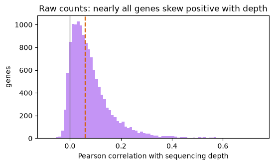

```python
# Before normalization, keeping a copy of the raw counts.
adata.layers["counts"] = adata.X.copy()

# Prefer to use pandas for this task
counts = pd.DataFrame(
    adata.X.toarray(),        # sparse -> dense numpy
    index=adata.obs_names,    # rows = cell barcodes
    columns=adata.var_names,  # cols = gene symbols
)

# Sequencing depth
depth = counts.sum(axis=1)  # sum horizontally across cols, gives one number per cell

# quantile(q) returns the value below which a fraction q of cells fall
# not using min/max bc those might be outliers
q05 = depth.quantile(0.05)      # 5% of cells are shallower than this value
q95 = depth.quantile(0.95)      # 5% of cells are deeper than this value
print(f"5th percentile:  {q05:,.0f} UMIs")
print(f"95th percentile: {q95:,.0f} UMIs")
print(f"ratio: {q95 / q05:.1f}x")


# Correlation of depth with gene level measurements
gene_depth_corr = counts.corrwith(depth).dropna()   # correlates each gene (col) with the depth Series
                                                    # lining the two up by cell barcode
print(f"median correlation: {gene_depth_corr.median():.2f}")
print(f"fraction of genes > 0: {(gene_depth_corr > 0).mean():.1%}")

# Plot histogram
fig, ax = plt.subplots(figsize=(6, 3.2))

ax.hist(gene_depth_corr, bins=80, color="#BA81F4", alpha=0.85)
ax.axvline(0, color="#767676", lw=1)                                    # reference: no correlation
ax.axvline(gene_depth_corr.median(), color="#D55E00", lw=1.6, ls="--")  # where genes actually sit

ax.set_xlabel("Pearson correlation with sequencing depth")
ax.set_ylabel("genes")
ax.set_title("Raw counts: nearly all genes skew positive with depth")
plt.show()
```

Sequencing depth still varies about 4.2-fold between typical shallow and deep cells (5th percentile: 1,013 UMIs, 95th percentile: 4,252 UMIs), even after filtering. The histogram shows that this variation leaks into the genes: 91.2% of genes correlate positively with depth, and almost none correlate negatively. Most correlations are weak (median 0.06), because most genes are detected in only a few cells and are almost always zero, which leaves little to correlate. However, the positive direction of the correlation is important because real biological signals might push genes both up and down, so having a shift to one side across the whole transcriptome supports the technical issue of a deeper cell having more of everything. For example, the long righthand tail, reaching about 0.6, contains the genes that are well expressed enough for this effect to show very clearly, and these same genes will likely drive the variance in PCA. The following normalization step will remove this technical effect.

```python
# norm = counts.div(counts.sum(axis=1), axis=0) * 1e4
    # in .sum, axis=1 means sum horizontally across columns (genes), give one number per cell
    # in .div, axis=0 means the resulting series should be matched to the ROW index (cells)

# I already defined counts.sum(axis=1) as depth above, so can use that:
norm = counts.div(depth, axis=0) * 1e4
```

Now, every count has been divided by the total count for that cell, and multiplied by a shared constant (10k), so that every cell's counts sums to 10k.

However, the normalization is not finished. This took care of the depth problem, but there is also the issue of scale.

#### 2. Scale Normalization

It is often the case that a few genes take up a large share of every cell's counts, and dominate the variance. Below I check if this is the case, by plotting the top-20 genes by:

1. For each cell, taking the percentage of that cell's counts that came from each gene.
2. Averaging those 2,643 percentages per gene. So if a gene shows 5, that means the typical cell has about 5% of its counts on this gene.

Plotting this is now easier since we normalized depth. Every cell now sums upto 10k, so norm/100 is already simply the percent of that cell's counts.

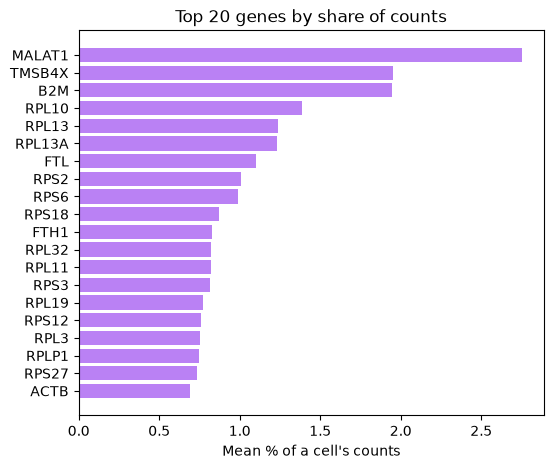

```python
pct = norm / 100
top20 = pct.mean().nlargest(20) # a Series: averages down each column, giving one avg value per gene
                                # We are interested in the largest 20

# Plotting
fig, ax = plt.subplots(figsize=(6, 5))
ax.barh(top20.index, top20.values, color = "#BA81F4")
ax.invert_yaxis() # barh draws the first item at the bottom, we want #1 at the top

ax.set_xlabel("Mean % of a cell's counts")
ax.set_title("Top 20 genes by share of counts")
plt.show()
```

As expected, some genes dominate. Together, these 20 genes (about 0.15% of the 13,714 retained) account for roughly 22% of a typical cell's counts. The largest, MALAT1, takes 2.75% on its own, while the median gene gets about 0.001%, so MALAT1 is thousands of times larger. The list also shows a pattern: 14 of the 20 are ribosomal protein genes (RPL*/RPS*), and together they account for about 13% of counts. The rest are other housekeeping genes: MALAT1 (a nuclear non-coding RNA), TMSB4X and ACTB (cytoskeleton), B2M (part of the MHC class I complex found on every nucleated cell), and FTL/FTH1 (ferritin). None of these are cell-type specific markers. So they are highly expressed in essentially every cell, but they carry little to no signal about what distinguishes a specific cell type.

One consideration is that, on a linear scale, a gene's variance will grow with its magnitude, meaning a 10% fluctuation in a gene like MALAT1 will be a far larger absolute change compared to a tenfold difference in a rare marker gene. The first components of PCA would thus be concentrated on capturing this noise in the housekeeping genes, which is not ideal.

To prevent this, another normalization step is necessary. A log transform step will compress this wide range, turning multiplicative differences into additive ones. After the transform, a doubling increase will count the same in the log scale regardless of whether it happens in MALAT1 or in a rare marker gene expressed much less.

```python
# Log1p normalize
logged = np.log1p(norm)
```

#### 3. Feature Selection

Finally, I want to do feature selection. The dataset has 13,714 genes, most of them vary due to sampling noise and would dilute the real signal that PCA needs to capture. For example, if a gene has 0.3 copies per cell on average it could just by chance show up as 0, 0, 1, 0, 0. Thousands of such genes would create noise which we can get rid of via feature selection.

Feature selection keeps genes whose variability is more than expected by chance. Importantly:

1. Using dispersion (variance/mean) instead of variance, in order to get rid of the effect that variance grows with the mean. Using dispersion removes most of the dependence on expression level, and point 2 below handles what remains. If we ranked genes by raw variance, we would get the highest expressed genes at top again.
2. Comparing each gene only with genes of similar expression, by first grouping genes into 20 "bins" by mean expression, then z-scoring the dispersion within each bin. This way, a gene's "score" represents how unusually variable it is compared to genes expressed around the same level as itself, which is more meaningful.
3. Finally, keeping the genes that pass three cutoffs --> the "highly variable genes" (HVGs)

I use the Seurat/Scanpy tutorial cutoffs (on the log scale of `hvg["mean"]`):

- **`mean > 0.0125`**: drops genes that are almost never detected. With nearly all zeros, their dispersion is estimated from a few counts and is not reliable.
- **`mean < 3`**: drops the most highly expressed genes. As seen in the top-20 plot, these are mostly housekeeping genes (ribosomal proteins, ACTB, B2M, FTL/FTH1) whose variation says little about cell type. Every bin gets z-scored on its own, including the sparse top bins, so a few of these still get high scores without this cutoff.
- **`disp_norm > 0.5`**: keeps only genes at least half a standard deviation more variable than the genes in their bin.

Another option is to just take the top 2k highly variable genes, but this would return 2k genes no matter how many are actually informative, so these cutoffs determine how many genes are actually meaningful to keep based on the data.

```python
# Using norm, which was depth-normalized, but before the log1p transform

mean = norm.mean()
var = norm.var()
disp = var / mean

# Seurat takes the log of both numbers:
hvg = pd.DataFrame({
    "mean": np.log1p(mean),
    "disp": np.log(disp),
})

# Bin by mean:
hvg["bin"] = pd.cut(hvg["mean"], bins=20)

# z-score within each bin
by_bin = hvg.groupby("bin", observed=True)["disp"]  # Groups the dispersions by bin
hvg["disp_norm"] = (hvg["disp"] - by_bin.transform("mean")) / by_bin.transform("std")   # transform("mean") returns a Series
                                                                                        # every gene gets its own bin's mean

# Keep genes passing all three cutoffs (Seurat/Scanpy tutorial defaults)
keep = (
    (hvg["mean"] > 0.0125)      # not almost-never detected
    & (hvg["mean"] < 3)         # not the very highly expressed housekeeping genes
    & (hvg["disp_norm"] > 0.5)  # more variable than genes of similar expression
)                               # NaN > 0.5 is False, so the unscored gene is dropped too
hvg_genes = hvg.index[keep]
```

```python
# Checking the HVG selection
print(f"{len(hvg_genes)} HVGs selected of {len(hvg)} genes")
print(f"{hvg['disp_norm'].isna().sum()} gene(s) with no score (alone in its bin, so no std)")
print()

# What did each mean cutoff remove, among genes that were variable enough?
variable = hvg["disp_norm"] > 0.5
print(f"disp_norm > 0.5:           {variable.sum()} genes")
print(f"  removed by mean <= 0.0125: {(variable & (hvg['mean'] <= 0.0125)).sum()}")
print(f"  removed by mean >= 3:      {(variable & (hvg['mean'] >= 3)).sum()}")
print(f"  {hvg.index[variable & (hvg['mean'] >= 3)].tolist()}")
print()

# Did the housekeeping genes from the top-20 plot survive?
print(f"top-20 genes kept as HVGs: {top20.index.isin(hvg_genes).sum()} of 20")

# Are known PBMC markers in?
markers = pd.Index(["LYZ", "MS4A1", "NKG7", "CD3E", "PPBP", "FCGR3A"])
print(pd.Series(markers.isin(hvg_genes), index=markers))
print()

# The highest-scoring genes (hvg_genes is no longer sorted by score, so sort first)
print(hvg.loc[hvg_genes].sort_values("disp_norm", ascending=False).head(10).round(2))
```

```
1844 HVGs selected of 13714 genes
1 gene(s) with no score (alone in its bin, so no std)

disp_norm > 0.5:           1993 genes
  removed by mean <= 0.0125: 128
  removed by mean >= 3:      21
  ['S100A9', 'S100A4', 'RPS27A', 'RPL34', 'RPS3A', 'CD74', 'HLA-DRA', 'ACTB', 'RPL8', 'FTH1', 'LYZ', 'RPL21', 'B2M', 'RPL13', 'H3F3B', 'OAZ1', 'JUNB', 'RPL18A', 'FTL', 'RPS5', 'MT-CO2']

top-20 genes kept as HVGs: 0 of 20
LYZ       False
MS4A1      True
NKG7       True
CD3E      False
PPBP       True
FCGR3A     True
dtype: bool

              mean  disp                bin  disp_norm
DOK3          0.28  5.84  (-0.00453, 0.282]       8.06
ARVCF         0.13  5.81  (-0.00453, 0.282]       8.00
YPEL2         0.25  5.81  (-0.00453, 0.282]       8.00
UBE2D4        0.26  5.78  (-0.00453, 0.282]       7.94
FAM210B       0.27  5.73  (-0.00453, 0.282]       7.84
CTB-113I20.2  0.13  5.65  (-0.00453, 0.282]       7.70
GBGT1         0.18  5.63  (-0.00453, 0.282]       7.64
LRRIQ3        0.10  5.44  (-0.00453, 0.282]       7.27
MTIF2         0.22  5.37  (-0.00453, 0.282]       7.14
TTC8          0.08  5.25  (-0.00453, 0.282]       6.89
```

The cutoffs keep 1,844 genes. Of the 1,993 genes with `disp_norm > 0.5`, 128 were dropped as almost never detected and 21 as too highly expressed. The high-expression group is mostly what I wanted to remove: ribosomal proteins (RPL*/RPS*), ACTB, B2M, FTL/FTH1 and MT-CO2. None of the top-20 housekeeping genes remain.

However, the `mean < 3` cutoff also removes some real cell-type markers: LYZ and S100A9 (monocytes), and CD74 and HLA-DRA (antigen-presenting cells). LYZ has a normalized dispersion of 3.7, so it is actually variable, just very highly expressed. This is the price of a simple threshold.

Among the remaining markers, MS4A1 (B cells), NKG7 (NK and cytotoxic T cells), PPBP (platelets) and FCGR3A (CD16+ monocytes and NK cells) are kept. CD3E, the pan-T-cell marker, is not: its `disp_norm` is about -0.34, so it is slightly *less* variable than genes of similar expression. This is most likely not a failure of the method: T cells are the most common cell type in this sample, so CD3E is expressed in a large fraction of cells and does not stand out within its bin the way markers of rarer populations do.

Also, the highest-scoring genes are still low-expression genes from the lowest bin (DOK3, ARVCF, ...). The `mean > 0.0125` cutoff is very low, so it only removes the most extreme cases.

#### Storing the results

So far I have worked with pandas DataFrames in this section (for practice), but PCA and UMAP will read from the AnnData object, so I write the log-normalized values back into `adata.X`, keep a full-gene copy in `adata.raw` (for marker plots later), record the HVGs in `adata.var`, and then subset to the 1,844 HVGs.

```python
# Checking that the row/col order hasn't changed before writing back
assert logged.index.equals(adata.obs_names)
assert logged.columns.equals(adata.var_names)

adata.X = sparse.csr_matrix(logged.values)   # log-normalized values, back as a sparse matrix
adata.raw = adata                            # full-gene snapshot of the log-normalized data

adata.var["highly_variable"] = adata.var_names.isin(hvg_genes)
adata = adata[:, adata.var["highly_variable"]].copy()

print(adata)
```

```
AnnData object with n_obs × n_vars = 2643 × 1844
    obs: 'n_genes', 'total_counts', 'pct_mt'
    var: 'gene_ids', 'n_cells', 'highly_variable'
    layers: None (.X), 'counts'
```

## PCA

#### 1. Standardization

I first standardize the scale of the data. StandardScaler makes each column's mean = 0 and standard deviation = 1. This way, larger numerical ranges will not dominate the variance, everything will have equal weight. Which part of adata do I need to standardize? --> adata.obs holds one row per cell, adata.var holds one row per gene, they are both "metadata." What I need to scale is adata.X which is the expression matrix, the 2643 cells x 1844 genes of log-normalized values.

NOTE: StandardScaler by default works column by column. In adata.X, cells are rows and genes are columns. What I want to scale is each gene across cells. So that's OK here.

I also use fit_transform(), which is two steps combined:

1. fit learns the numbers from the data. For StandardScaler that's the mean and SD of every column (gene), which is then stored as scaler.mean_ and scaler.scale_.
2. transform then applies them: for every value, (value - column mean)/column SD. This is "z-scoring." So now the new values reflects how many SDs the gene is above or below the average.

However, since the z-scoring step involves division by SD, cells that express genes that aren't expressed in almost any other cell will get huge z-scores since the SD is very small for these genes. To account for this, below steps clip values at + or - 10.

```python
scaler = StandardScaler()
scaled = scaler.fit_transform(adata.X.toarray()) # need to add toarray() bc adata.X is a sparse matrix
scaled = np.clip(scaled, -10, 10) # clipping

adata.X = scaled

# Checking first 5 HVGs as example
print(scaled.mean(axis=0).round(3)[:5])
print(scaled.std(axis=0).round(3)[:5])
```

```
[ 0.    -0.001 -0.019  0.     0.   ]
[1.    0.99  0.556 1.    1.   ]
```

Without clipping, every gene would have a mean of exactly 0 and an SD of exactly 1. Three of the first five genes are like that, and the other two deviate because of clipping. Clipping matters for genes detected in only a few cells: for example, if a gene is detected in only 3 of the 2,643 cells, those 3 cells get a z-score of about √(2,643/3) ≈ 30, while every other cell has a z-score near 0. Clipping cuts those values down to 10, which shrinks the gene's spread (SD below 1). Because clipping only removes positive values here, it also moves the mean slightly below zero.

This is what happens to the third gene (ATAD3C): it is detected in only 9 cells, 7 of them get z-scores above 10 (up to about 36), and clipping brings its SD down to 0.56 and its mean to -0.02. The second gene (CPSF3L) is detected in about 200 cells, and only one of them is clipped (from about 12 to 10), so its SD barely moves (0.99). The other three genes are expressed in 150-600 cells, never exceed ±10, and are untouched.

This is intended. However, on another note, genes like ATAD3C show that my HVG list contains genes detected in only a small number of cells, which is a consequence of the low `mean > 0.0125` cutoff above. I could have been more strict there. But, since this is a learning exercise, I will continue as it is.

#### 2. PCA

Similar to the standardization step above, fit_transform here does two things:

1. fit finds the directions of variance in a space with 1844 axes, one axis per gene, where cells are spread out as points. Each direction is a list of 1844 weights, one per gene. It records how much variance each direction captures. For example: PC1 --> the direction through the cloud of points along which the cells are most spread out.
2. transform then places each cell on those directions. For each cell and each PC, it computes a weighted sum: the cell's value for each gene × that gene's weight, added up over all 1,844 genes. The result is the cell's score on that PC. So it gives each cell a score on each direction, which is a 2,643 × 50 table.

```python
pca = PCA(n_components=50, random_state=0)  # random state makes result reproducible
X_pca = pca.fit_transform(adata.X)

adata.obsm["X_pca"] = X_pca     # adata.obsm holds a whole array per cell (X_pca : 50 numbers per cell)

# Checks:
print(X_pca.shape)
print(pca.components_.shape)
print(pca.explained_variance_ratio_[:5].round(4))
```

```
(2643, 50)
(50, 1844)
[0.0219 0.0118 0.0097 0.0083 0.0052]
```

### 3. Looking at the PCs

I have so far computed the 50 PCs, but I haven't looked at them yet.

#### a. Scree plot

The first thing I will do is a scree plot. pca.explained_variance_ratio_ holds 50 values, each being the fraction of total variance captured by that PC. A scree plot is the bar chart that represents them, with PC number on the x-axis and the % variance on the y-axis. I'll be looking for the point where the bars flatten out, which is likely mostly noise.

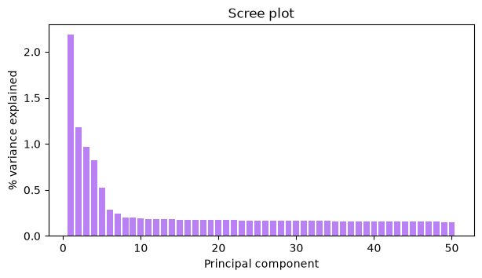

```python
pcs = np.arange(1, 51)  # a range from 1...50, for each PC
var_pct = pca.explained_variance_ratio_ * 100   # fraction --> percentage

fig, ax = plt.subplots(figsize=(7,3.5))
ax.bar(pcs, var_pct, color="#BA81F4")
ax.set_xlabel("Principal component")
ax.set_ylabel("% variance explained")
ax.set_title("Scree plot")
plt.show()
```

PC1 is about 2.2%, then PC2 about 1.2%, PC3 1%, PC4 0.8%, PC5 0.5%, and after about PC10 the bars become almost flat. This is the expected shape. One note is that all 50 PCs together only explain about 13.5% variance, but that is due to the scaling step completed previously; scaling gave each of the 1844 genes a variance of 1, so the total being divided up is 1844, and most of it is noise.

I now have to decide how many PCs to focus on. From the scree plot alone the first 10 PCs seems like a possible choice, but rather than guessing I will first calculate the noise floor and compare every PC to that, in order to quantify how many times bigger it is than noise. I will set the noise floor as the median value of PCs 21-50, since those look almost completely flat.

```python
noise_floor = np.median(var_pct[20:])   # typical % explained by a "noise" PC (PCs 21-50)
ratio = var_pct / noise_floor   # how many times bigger than noise each PC is

print(f"noise floor: {noise_floor:.3f}%")
print(ratio[:12].round(2))
```

```
noise floor: 0.161%
[13.56  7.33  6.02  5.12  3.24  1.76  1.51  1.26  1.25  1.19  1.14  1.13]
```

The noise floor is about 0.16%. The ratios start around 13–14 for PC1, then about 7, 6, 5, 3 for PCs 2–5. After that they drop to roughly 1.2–1.8 for PCs 6–9 and flatten close to 1.

PCs 1–5 are clearly signal. PCs 6–10 are only a bit above the noise floor, but they aren't fully flat, and rare cell types (like platelets or dendritic cells) might appear in these weak PCs. I'll move forward with 10 PCs.

```python
n_pcs = 10 # can change later if needed
```

#### b. Genes

Next I will look into what the PCs consist of. pca.components_ has shape (50, 1844): one row per PC and one weight per gene. A large positive or negative weight means that gene has a big influence on that PC. Genes with opposite signs pull cells in opposite directions along the PC. I'll first build a data frame with genes as rows and PC1, PC2 as columns, then list the top genes on each side of PC1.

```python
loadings = pd.DataFrame(
    pca.components_.T[:, :2],
    index=adata.var_names,  # rows = gene names
    columns=["PC1", "PC2"],
)

pc1 = loadings["PC1"].sort_values()
print("PC1 negative side:", pc1.head(10).index.tolist())
print("PC1 positive side:", pc1.tail(10).index.tolist())    # tail -> ascending order, last gene is strongest

pc2 = loadings["PC2"].sort_values()
print("PC2 negative side:", pc2.head(10).index.tolist())
print("PC2 positive side:", pc2.tail(10).index.tolist())
```

```
PC1 negative side: ['PTPRCAP', 'IL32', 'LTB', 'CD2', 'CTSW', 'CD247', 'ACAP1', 'STK17A', 'HINT1', 'CCL5']
PC1 positive side: ['LGALS2', 'S100A8', 'LGALS1', 'FCER1G', 'TYMP', 'FCN1', 'AIF1', 'LST1', 'TYROBP', 'CST3']
PC2 negative side: ['CD79A', 'MS4A1', 'TCL1A', 'HLA-DQA1', 'HLA-DQB1', 'LINC00926', 'CD79B', 'LTB', 'CD37', 'HLA-DRB1']
PC2 positive side: ['GZMH', 'SPON2', 'CTSW', 'GNLY', 'FGFBP2', 'GZMA', 'CST7', 'PRF1', 'GZMB', 'NKG7']
```

Both PCs separate known PBMC cell types, even though PCA wasn't given any cell labels. That's good.

PC1: lymphocytes vs. myeloid cells. The negative side is T-cell and lymphocyte genes: IL32, LTB, CD2 and CD247 (part of the T-cell receptor complex), plus PTPRCAP. The positive side is monocyte genes: CST3, TYROBP, LST1, AIF1, FCN1 and S100A8. The strongest single gene is CST3. The biggest source of variation in the data is the split between lymphocytes and monocytes.

PC2: B cells vs. NK / cytotoxic cells. The negative side is B-cell genes: CD79A and CD79B (the B-cell receptor), MS4A1 (CD20) and TCL1A. It also has HLA class II genes (HLA-DQA1, HLA-DQB1, HLA-DRB1), which B cells use to present antigens. The positive side is cytotoxic genes: NKG7, GZMB, GZMA, GZMH, PRF1 (perforin) and GNLY.

A few genes show up in more than one place, which makes sense biologically. CTSW and CCL5 are on the T side of PC1 and (CTSW) on the cytotoxic side of PC2, because cytotoxic T cells are lymphocytes that share killing genes with NK cells. LTB is on the lymphocyte side of PC1 and the B-cell side of PC2, because both T and B cells express it.

Note: The sign of each PC is arbitrary. PCA could have as well put T cells on the positive side. Only the grouping of genes matters.

#### c. Cells

The loadings showed me which genes make up the PCs. Now I'll look into the cells. X_pca[:, 0] is every cell's PC1 score and X_pca[:, 1] is its PC2 score. I will plot them against each other, then color each cell by how much it expresses a marker gene. The logged DataFrame still has all 13,714 genes, and its rows are in the same cell order as X_pca, so I can use it to get a cell's expression.

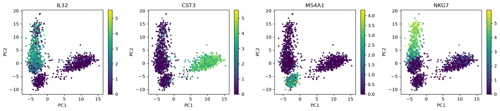

```python
genes = ["IL32", "CST3", "MS4A1", "NKG7"]   # T cell, monocyte, B cell, NK

fig, axes = plt.subplots(1, 4, figsize=(16, 3.6))

for ax, gene in zip(axes, genes):
    points = ax.scatter(X_pca[:, 0], X_pca[:, 1], c=logged[gene], s=5, cmap="viridis")
    fig.colorbar(points, ax=ax)
    ax.set_title(gene)
    ax.set_xlabel("PC1")
    ax.set_ylabel("PC2")

fig.tight_layout()
plt.show()
```

So, each panel shows the same 2,643 cells at their PC1/PC2 scores, colored by one marker gene. All four genes "light up" (i.e. highly expressed) where the loadings predicted, so the gene weights and the cell scores agree:

- CST3 (monocytes) is high in the separate cloud on the right (positive PC1).
- IL32 (T cells) is high on the left (negative PC1).
- MS4A1 (B cells) is high in the small island at the bottom left (negative PC2).
- NKG7 (NK and cytotoxic cells) is high at the top left (positive PC2).

These two PCs alone separate three main groups: monocytes, B cells, and a large T/NK group. The monocytes and B cells form distinct islands. T cells and NK cells don't. They form one continuous column on the left, with NKG7 rising from the middle toward the top and no clear gap. That makes biological sense to me: cytotoxic T cells express NKG7 too, so they sit between "regular" T cells and NK cells.

A few cells sit in the gap between the left group and the monocyte cloud. From this plot alone I can't tell whether they're a rare cell type, cells in transition, or doublets. Because of this, it will be useful when I use all 10 PCs at once in the next step.

## k-Nearest Neighbor Graph + Clustering

So, I will look into which cells are most similar to each cell across all 10 PCs, using a k-nearest-neighbor graph. Leiden clustering will find groups of cells that are densely connected to each other.

```python
nn = NearestNeighbors(n_neighbors=15)
nn.fit(X_pca[:, :n_pcs])    # learns where every cell is in the 10-PC space
distances, indices = nn.kneighbors(X_pca[:, :n_pcs]) # 15 closest neighbors for each cell

print(indices.shape)
# Test: are a B cell's neighbors also B cells?
b_cell = logged["MS4A1"].idxmax()          # barcode of the strongest MS4A1 cell
row = logged.index.get_loc(b_cell)         # barcode -> row number
neighbor_ids = indices[row]                # its 15 neighbors (row numbers)

print("first 5 neighbors:", neighbor_ids[:5])
print("first 3 distances:", distances[row][:3].round(2))
print("MS4A1 in its neighbors:", logged["MS4A1"].iloc[neighbor_ids].mean().round(2))
print("MS4A1 in all cells:    ", logged["MS4A1"].mean().round(2))
```

```
(2643, 15)
first 5 neighbors: [  18  107  281 1332  366]
first 3 distances: [0.   3.23 3.65]
MS4A1 in its neighbors: 2.14
MS4A1 in all cells:     0.35
```

Neighbor search works as expected. Every cell now has a list of its 15 closest cells across all 10 PCs, so `indices` has shape (2643, 15). The first neighbor of every cell is the cell itself at distance 0, because a cell is always closest to itself. For the cell with the highest MS4A1 (a clear B cell), the average MS4A1 among its neighbors is 2.14, compared with 0.35 across all cells, so its neighbors are mostly B cells too. This is a good indication that distance in PC space mostly tracks cell type.

#### Scanpy's neighbor graph + Leiden clustering

Scanpy builds the same kind of 15-neighbor graph. As a difference, though, it gives every link a weight (closer neighbors count more), and it stores the graph in `adata.obsp` so that Leiden and UMAP can use it. Leiden looks for groups of cells that have many links among themselves and few links to the rest of the graph. `resolution` controls how fine these groups are: higher values give more, smaller clusters. Iwill start with the default of 1.0.

```python
sc.pp.neighbors(adata, n_neighbors=15, n_pcs=n_pcs)   # reads adata.obsm["X_pca"], builds the weighted kNN graph
sc.tl.leiden(adata, resolution=1.0, random_state=0)   # adds adata.obs["leiden"]

print(adata.obs["leiden"].value_counts())
```

```
leiden
0     480
1     477
2     353
3     325
4     236
5     204
6     198
7     178
8     143
9      34
10     15
Name: count, dtype: int64
```

Leiden found 11 clusters at resolution 1.0, ranging from 480 cells down to 34 and 15 cells. The clusters are only numbers, so to find out what they are I will check the mean expression of known PBMC markers in each cluster. I will use `groupby` since both `logged` and `adata.obs` use the cell barcodes as their index, so pandas will line up each cell with its cluster.

```python
# Mean expression of known PBMC markers in each cluster
markers = ["IL7R", "CCR7", "CD8A", "MS4A1", "CD14", "LYZ", "FCGR3A", "NKG7", "GNLY", "FCER1A", "PPBP"]

cluster_means = logged[markers].groupby(adata.obs["leiden"]).mean()   # one row per cluster, one col per marker
print(cluster_means.round(1))
```

```
        IL7R  CCR7  CD8A  MS4A1  CD14  LYZ  FCGR3A  NKG7  GNLY  FCER1A  PPBP
leiden
0        1.6   0.8   0.1    0.1   0.0  0.9     0.1   0.2   0.2     0.0   0.0
1        1.3   0.7   0.3    0.1   0.0  0.9     0.1   0.2   0.1     0.0   0.0
2        0.2   0.3   0.1    2.1   0.0  0.9     0.1   0.2   0.2     0.0   0.0
3        1.1   0.1   1.0    0.1   0.0  0.8     0.5   3.3   1.0     0.0   0.0
4        0.2   0.0   0.0    0.1   1.2  4.8     0.2   0.2   0.2     0.0   0.1
5        0.2   0.0   0.0    0.1   1.9  5.3     0.1   0.4   0.2     0.0   0.1
6        0.2   0.1   0.0    0.1   0.5  3.5     2.5   0.5   0.2     0.0   0.1
7        1.6   0.4   0.2    0.1   0.0  1.1     0.1   0.4   0.2     0.0   0.0
8        0.2   0.0   0.2    0.1   0.0  0.8     2.3   4.8   4.2     0.0   0.0
9        0.4   0.1   0.0    0.1   0.3  4.7     0.2   0.4   0.3     2.2   0.0
10       0.2   0.0   0.0    0.1   0.1  1.6     0.2   0.3   0.1     0.0   5.7
```

Every cluster has a clear marker pattern:

| Cluster | Cells | High markers | Likely cell type |
| --- | --- | --- | --- |
| 0, 1 | 480, 477 | IL7R, CCR7 | CD4 T cells (naive) |
| 7 | 178 | IL7R, lower CCR7 | CD4 T cells (memory) |
| 3 | 325 | CD8A, NKG7 | CD8 T cells |
| 8 | 143 | NKG7, GNLY, FCGR3A | NK cells |
| 2 | 353 | MS4A1 | B cells |
| 4, 5 | 236, 204 | CD14, LYZ | CD14+ monocytes |
| 6 | 198 | FCGR3A, LYZ | FCGR3A+ (CD16+) monocytes |
| 9 | 34 | FCER1A, LYZ | Dendritic cells |
| 10 | 15 | PPBP | Platelets |

The two smallest clusters, dendritic cells and platelets, were not visible at all in the PC1/PC2 plot, so using all 10 PCs was worth it.

Some caveats:

- Clusters 0 and 1 look almost the same with these markers (cluster 1 has slightly more CD8A, 0.3 vs 0.1). From this table alone I can't say what separates them; I would need to compare all genes between the two clusters to know. The same goes for clusters 4 and 5, which may be one monocyte population split in two.
- The naive vs memory label for cluster 7 rests only on a small difference in CCR7 (0.4 vs 0.7–0.8).
- LYZ is around 0.8–1.1 even in the T and B cell clusters. This is probably background.

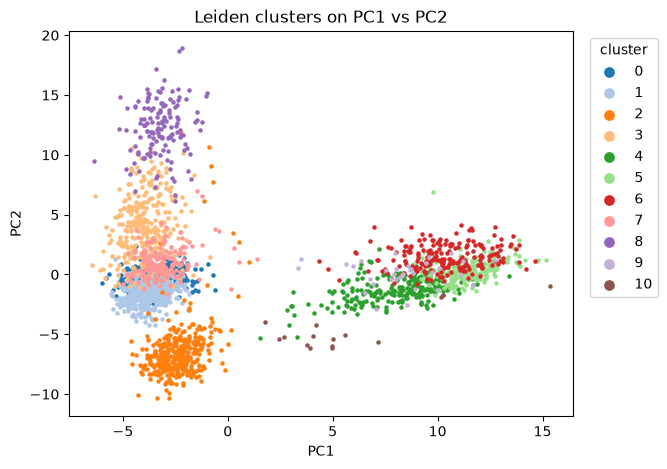

```python
fig, ax = plt.subplots(figsize=(6.5, 5))

for i, cluster in enumerate(adata.obs["leiden"].cat.categories):
    mask = (adata.obs["leiden"] == cluster).values      # True for cells in this cluster
    ax.scatter(X_pca[mask, 0], X_pca[mask, 1], s=5, color=plt.cm.tab20(i), label=cluster)   # tab20: 20 distinct colors

ax.set_xlabel("PC1")
ax.set_ylabel("PC2")
ax.set_title("Leiden clusters on PC1 vs PC2")
ax.legend(title="cluster", markerscale=3, bbox_to_anchor=(1.02, 1), loc="upper left")
plt.show()
```

The clusters line up with the groups from the marker plots: B cells (2) form the bottom-left island, the monocytes (4, 5, 6) and dendritic cells (9) make up the cloud on the right, and the left column goes from CD4 T cells (0, 1, 7) at the bottom, through CD8 T cells (3), to NK cells (8) at the top. The platelets (10) are most of the cells in the gap between the two groups that I could not explain earlier, so they are a rare cell type rather than cells in transition. (Some could still be doublets, but a mean PPBP of 5.7 suggests a platelet signal.)

Many clusters overlap here: 0, 1 and 7 lie on top of each other, and 9 sits inside the monocyte cloud. The clusters were found using all 10 PCs, and this plot only shows 2, so differences along PC3–PC10 are not visible in this plot. This problem will be solved by UMAP in the next step, since it will draw the whole 10 PC neighbor graph in 2D!

## UMAP

```python
reducer = umap.UMAP(n_neighbors=15, min_dist=0.5, random_state=0)
X_umap = reducer.fit_transform(X_pca[:, :n_pcs])    # 10 PCs go in, 2 coordinates out

adata.obsm["X_umap"] = X_umap

print(X_umap.shape)
```

```
(2643, 2)
```

The shape is as expected: (2643, 2) -- two numbers per cell. Now, I will plot UMAP and PCA together, to compare.

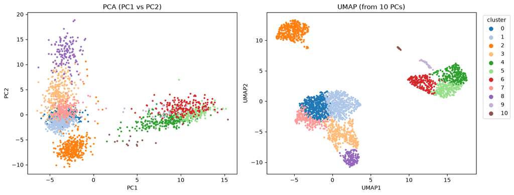

```python
fig, axes = plt.subplots(1, 2, figsize=(13, 5))

for i, cluster in enumerate(adata.obs["leiden"].cat.categories):
    mask = (adata.obs["leiden"] == cluster).values
    color = plt.cm.tab20(i)
    axes[0].scatter(X_pca[mask, 0], X_pca[mask, 1], s=5, color=color)
    axes[1].scatter(X_umap[mask, 0], X_umap[mask, 1], s=5, color=color, label=cluster)

axes[0].set_title("PCA (PC1 vs PC2)")
axes[0].set_xlabel("PC1")
axes[0].set_ylabel("PC2")

axes[1].set_title("UMAP (from 10 PCs)")
axes[1].set_xlabel("UMAP1")
axes[1].set_ylabel("UMAP2")
axes[1].legend(title="cluster", markerscale=3, bbox_to_anchor=(1.02, 1), loc="upper left")

fig.tight_layout()
plt.show()
```

Both plots show the same 2,643 cells with the same cluster colors, but they look quite different.

- In the PCA plot, the CD4 T cell clusters (0, 1, 7) lie on top of each other, and the dendritic cells (9) are hidden inside the monocyte cloud. In UMAP, 0, 1 and 7 sit next to each other instead of overlapping, and the dendritic cells form their own small strip at the edge of the monocytes. This is because UMAP uses all 10 PCs (through its neighbor graph), while the PCA plot only shows 2 of them. Clusters 0 and 1 also still touch with no gap between them, which fits with the T cells being a continuum rather than separate groups.
- UMAP keeps neighbors instead of distances. For example, the platelets (10) sit in the gap between the lymphocytes and the monocytes in PCA, which means they score low on both the T-cell and monocyte genes of PC1 and PC2. In UMAP they become a tiny island far away from everything else. UMAP only tries to keep each cell close to its own neighbors. The 15 platelets are mostly each other's neighbors, so they get pulled together, but where that island ends up relative to the other islands isn't so meaningful. The same goes for the B cells: in PCA they share the negative PC1 side with the T cells, because both are lymphocytes, but in UMAP the B cell island looks far from the T cells.
- UMAP also changes the sizes and spreads of the groups. In PCA, the NK cells (8) are the most spread-out group, stretching along PC2 from about 5 to 19. In UMAP they are a small, compact blob. UMAP tends to even out how spread out each group looks, so the size of an island doesn't inform about how varied the cells inside it are.
- Finally, of course, the UMAP axes have no meaning. PC1 has a direction one can interpret ("lymphocytes vs monocytes") as well as a list of gene weights behind it. UMAP1 and UMAP2 have no units, and it could be rotated or flipped and still be valid. So the numbers on the UMAP axes and distances between islands can not be read as amounts of difference between cell types.

Summary: PCA is the more honest representation of large-scale distances but only shows 2 dimensions at a time, while UMAP shows the local structure of all 10 PCs well but distorts everything between and inside the islands.

## Varying UMAP settings

Next I will vary settings of the UMAP to see how much the output depends on the settings (and how).

UMAP has two main settings:

- `n_neighbors`: how many neighbors each cell is linked to in the graph. Small values make UMAP focus on very local structure, while large values make it focus more on the overall shape.
- `min_dist`: how tightly UMAP packs points together in 2D. 0: very tight clumps are allowed, 1: points are forced to spread out.

I keep the data (the 10 PCs) and the random seed fixed, and change one setting at a time away from the settings I used above (`n_neighbors=15`, `min_dist=0.5`). Since I will draw many cluster-colored plots from here on, I first put my scatter loop into a small function, `plot_clusters`, so I don't have to repeat it.

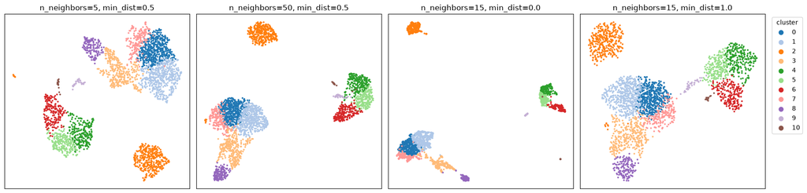

```python
# A helper so I don't have to repeat the cluster-colored scatter loop for every plot
def plot_clusters(ax, coords, title):
    for i, cluster in enumerate(adata.obs["leiden"].cat.categories):
        mask = (adata.obs["leiden"] == cluster).values
        ax.scatter(coords[mask, 0], coords[mask, 1], s=3, color=plt.cm.tab20(i), label=cluster)
    ax.set_title(title)
    ax.set_xticks([])   # UMAP/t-SNE axis numbers carry no meaning, so I hide them
    ax.set_yticks([])


settings = [(5, 0.5), (50, 0.5), (15, 0.0), (15, 1.0)]   # (n_neighbors, min_dist)

fig, axes = plt.subplots(1, 4, figsize=(18, 4.4))

for ax, (k, d) in zip(axes, settings):
    coords = umap.UMAP(n_neighbors=k, min_dist=d, random_state=0).fit_transform(X_pca[:, :n_pcs])
    plot_clusters(ax, coords, f"n_neighbors={k}, min_dist={d}")

axes[-1].legend(title="cluster", markerscale=4, bbox_to_anchor=(1.02, 1), loc="upper left")
fig.tight_layout()
plt.show()
```

All four panels show the same 2,643 cells and the same 10 PCs, with different settings:

- **`n_neighbors=5`**: the picture breaks into more separate pieces. The NK cells (8) and CD8 T cells (3) pull away from the CD4 T cells, a few B cells split off into small islands, and the big groups are arranged differently (the B cells move to another corner). With only 5 neighbors, UMAP only sees very local structure, so it knows little about how the groups relate to each other.
- **`n_neighbors=50`**: very close to my original UMAP with 15. The CD4 T → CD8 T → NK chain stays connected.
- **`min_dist=0.0`**: the same groups, but packed into very tight clumps with a lot of empty space between them. The CD8 T cells (3) become a thin slice. These look like very distinct cell types, even though nothing about the data is changed.
- **`min_dist=1.0`**: the opposite. The groups appear "puffed up" and they fill the space, the gaps have shrunk, the monocytes, dendritic cells and platelets are almost touching like a continuous population.

However, across the four, each Leiden cluster stays together, and the same clusters are neighbors (CD4 T next to CD8 T next to NK). Only things that change are visual i.e. how far apart the groups look, how compact they look, and where they are placed relative to each other. So statements like "these two populations are clearly distinct" or "this population is very heterogeneous," when made based only on a UMAP, are dependent on the settings picked.

## t-SNE

I would like to see how t-SNE compares to UMAP. t-SNE is an older method with the same goal: placing the cells in 2D so that cells that are neighbors in the 10-PC space stay neighbors. Its main setting is `perplexity`, which is the number of neighbors each cell "pays attention to" (the default is 30). I use sklearn's `TSNE` with the same input as UMAP (the 10 PCs) and a fixed `random_state`, and plot it next to PCA and UMAP.

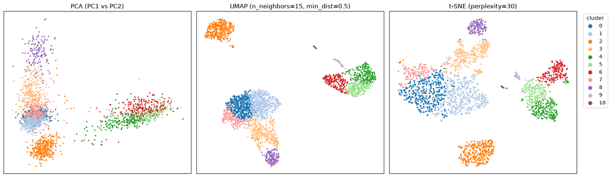

```python
tsne = TSNE(n_components=2, perplexity=30, random_state=0)
X_tsne = tsne.fit_transform(X_pca[:, :n_pcs])    # same input as UMAP: the 10 PCs

adata.obsm["X_tsne"] = X_tsne

fig, axes = plt.subplots(1, 3, figsize=(17, 5))
plot_clusters(axes[0], X_pca[:, :2], "PCA (PC1 vs PC2)")
plot_clusters(axes[1], X_umap, "UMAP (n_neighbors=15, min_dist=0.5)")
plot_clusters(axes[2], X_tsne, "t-SNE (perplexity=30)")

axes[-1].legend(title="cluster", markerscale=4, bbox_to_anchor=(1.02, 1), loc="upper left")
fig.tight_layout()
plt.show()
```

When it comes to local structure, UMAP and t-SNE both show the same groups (B cells, CD4 T, CD8 T, NK, monocytes, dendritic cells, platelets), and both keep each Leiden cluster together. Since both start from the same 10 PCs and both try to keep neighbors together, this makes sense.

However they differ in multiple ways:

- t-SNE spreads the cells out more evenly; the CD4 T cells (0, 1), the two largest clusters, take up a large part of the t-SNE plot, while in UMAP they form one compact group. t-SNE tends to give large clusters a large area, so the size of an island is indicative of how many cells it has rather than about how varied they are.
- The groups are also placed differently. For example in UMAP the B cells sit in a corner and the platelets near the monocytes, but in t-SNE the B cells are at the bottom and the platelets are a tiny circle between the T cells and the monocytes. Neither placement can be selected as correct because neither method tries to keep the distances between groups.

Next, I will change t-SNE's main setting (perplexity) and see how that influences the outcome.

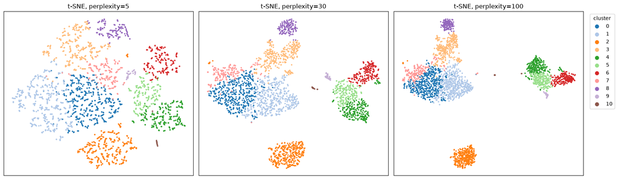

```python
fig, axes = plt.subplots(1, 3, figsize=(17, 5))

for ax, perp in zip(axes, [5, 30, 100]):
    coords = TSNE(n_components=2, perplexity=perp, random_state=0).fit_transform(X_pca[:, :n_pcs])
    plot_clusters(ax, coords, f"t-SNE, perplexity={perp}")

axes[-1].legend(title="cluster", markerscale=4, bbox_to_anchor=(1.02, 1), loc="upper left")
fig.tight_layout()
plt.show()
```

With perplexity=5, each cell only pays attention to a few neighbors. Clusters break into small sub-clumps, and the gaps between groups become less obvious.

With perplexity=100, the groups become much more compact, with more empty space between them, more clearly separated.

As with UMAP, each cluster stays together at every setting, but how separated, how compact and how grainy the groups look depends on the setting.

## Conclusions

In this project, starting from raw counts of 2,700 blood cells, I went through quality control, normalization, feature selection and PCA, and found the main PBMC cell types, from large T cell populations down to 15 platelets. I compared three 2D pictures of the same data. PCA was more intuitive, with its axes and distances meaning something, but it only shows a small part of the data at a time. UMAP and t-SNE show all the groups at once and are good for seeing which cells belong together, but how far apart groups look, how big they look and how they are arranged depends on settings I chose. The main lesson for me is to treat a UMAP or t-SNE as a map of neighborhoods rather than distances, and to check any claim about how different or how varied cell types are against the PCs or the gene expression itself. As always, any feedback is welcome!